# The Project

1. This is a project with minimal scaffolding. Expect to use the the discussion forums to gain insights! It’s not cheating to ask others for opinions or perspectives!
2. Be inquisitive, try out new things.
3. Use the previous modules for insights into how to complete the functions! You'll have to combine Pillow, OpenCV, and Pytesseract
4. There are hints provided in Coursera, feel free to explore the hints if needed. Each hint provide progressively more details on how to solve the issue. This project is intended to be comprehensive and difficult if you do it without the hints.

### The Assignment

Take a ZIP file) of images and process them, using a [library built into python](https://docs.python.org/3/library/zipfile.html) that you need to learn how to use. A ZIP file takes several different files and compresses them, thus saving space, into one single file. The files in the ZIP file we provide are newspaper images (like you saw in week 3). Your task is to write python code which allows one to search through the images looking for the occurrences of keywords and faces. E.g. if you search for "pizza" it will return a contact sheet of all of the faces which were located on the newspaper page which mentions "pizza". This will test your ability to learn a new ([library](https://docs.python.org/3/library/zipfile.html)), your ability to use OpenCV to detect faces, your ability to use tesseract to do optical character recognition, and your ability to use PIL to composite images together into contact sheets.

Each page of the newspapers is saved as a single PNG image in a file called images.zip. These newspapers are in english, and contain a variety of stories, advertisements and images. Note: This file is fairly large (~200 MB) and may take some time to work with, I would encourage you to use small_img.zip for testing.

Here's an example of the output expected. Using the small_img.zip file, if I search for the string "Christopher" I should see the following image:

[figure not shown]

If I were to use the images.zip file and search for "Mark" I should see the following image (note that there are times when there are no faces on a page, but a word is found!):

[figure not shown]

```
Word input to search in small_data.zip: Christopher
Results for "Christopher" in small_img.zip:
Results found in file a-0.png
```

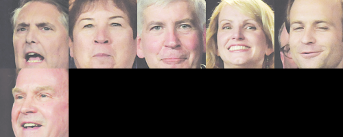

```
Results found in file a-3.png
```

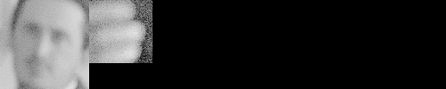

```
Word input to search in images.zip: Mark
Results for "Mark" in images.zip:
Results found in file a-0.png
```

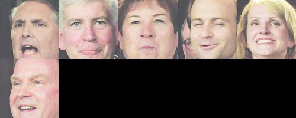

```
Results found in file a-1.png
```

[figure not shown]

```
Results found in file a-10.png
But there were no faces in that file!
Results found in file a-13.png
```

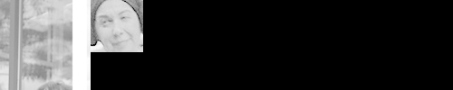

```
Results found in file a-2.png
```

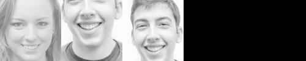

```
Results found in file a-3.png
```

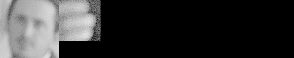

```
Results found in file a-8.png
```

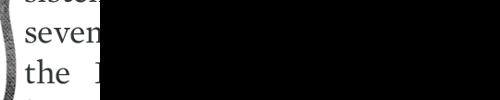

```python
import zipfile

from PIL import Image, ImageDraw
import pytesseract
import cv2 as cv
import numpy as np

# Initiate Face Detection Multiplier
face_cascade = cv.CascadeClassifier('readonly/haarcascade_frontalface_default.xml')

# Function for Unzipping and Extraction of Files
def extract_data(file_name):
    with zipfile.ZipFile(file_name, 'r') as myzip:
        img_list = []
        for myfile in myzip.namelist():
            img_dict = {}
            # File name
            img_dict['name'] = myfile
            # File path
            file_path = zipfile.ZipFile.extract(myzip,member=myfile)
            img_dict['path'] = file_path
            # Save image
            img_pil = Image.open(file_path,'r')
            img_dict['img'] = img_pil
            # Extract text
            text = pytesseract.image_to_string(img_pil).replace('\n',' ')
            img_dict['text'] = text
            # Extract faces
            img_cv = cv.imread(file_path)
            img_cv_gray = cv.cvtColor(img_cv,cv.COLOR_BGR2GRAY)
            faces = face_cascade.detectMultiScale(img_cv_gray,1.35)
            if type(faces) is tuple:
                faces = []
            else:
                faces = faces.tolist()
            img_dict['faces'] = faces

            # Append to the list
            img_list.append(img_dict)
    return img_list
# Function Display Faces
def display_faces(img_input):
    contact_sheet = Image.new(img_input['img'].mode, (500,100*(len(img_input['faces'])//5+1)))
    x = 0
    y = 0
    for face in img_input['faces']:
        box = (face[0],face[1],face[2]+face[0],face[3]+face[1])
        img_crop = img_input['img'].crop(box)
        img_crop.thumbnail((100,100))
        contact_sheet.paste(img_crop,(x,y))
        if x<400:
            x += 100
        else:
            x = 0
            y += 100
    display(contact_sheet)
# Search in small_img.zip files
word = input('Word input to search in small_data.zip: ')
img_list = extract_data('readonly/small_img.zip')

print('Results for "{}" in small_img.zip: '.format(word))
for img in img_list:
    if word in img['text']:
        print('Results found in file {}'.format(img['name']))
        if img['faces'] != []:
            display_faces(img)
        else:
            print('But there were no faces in that file!')

# Search in small_img.zip files
word = input('Word input to search in images.zip: ')
img_list = extract_data('readonly/images.zip')

print('Results for "{}" in images.zip: '.format(word))
for img in img_list:
    if word in img['text']:
        print('Results found in file {}'.format(img['name']))
        if img['faces'] != []:
            display_faces(img)
        else:
            print('But there were no faces in that file!')
```